# Project_Tennis

Effy Fang

August 25, 2019

```r
library(fpp)
library(TSA)
library(ggplot2)
library(vars)
```

## data preparation

[figure not shown]

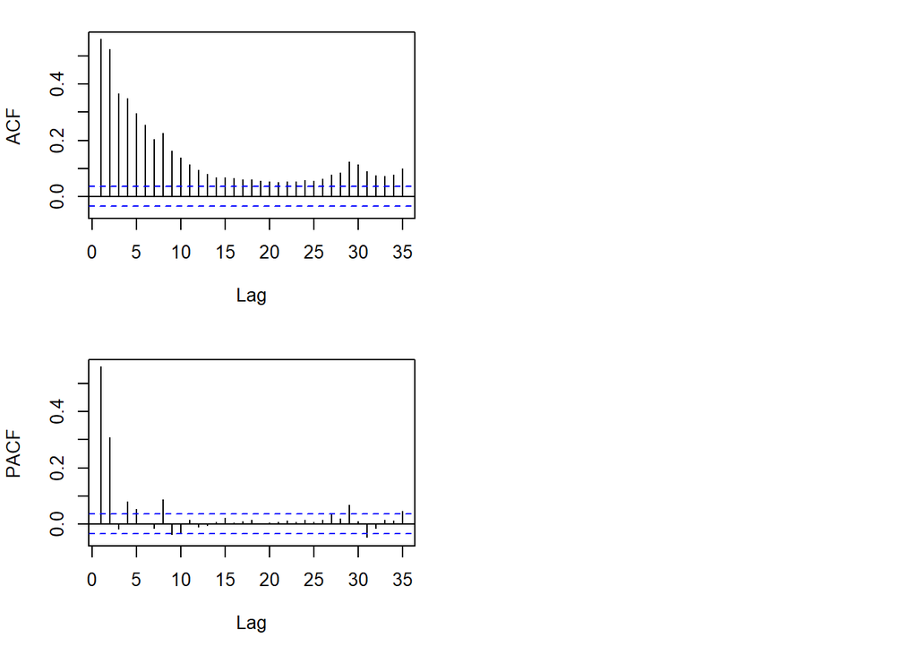

```r
datapath <- "C:/Users/effyf/Documents/MSCA/time series/project/TimeSeries-Project/TSProject"
project.dat<-readRDS(file=paste(datapath,"new_train.rda",sep="/"))
#head(project.dat)
tennis.en=as.integer(project.dat[,6])
tennis.fr=as.integer(project.dat[,7])
tennis.es=as.integer(project.dat[,8])
tennis.de=as.integer(project.dat[,9])
tennis=cbind(en=tennis.en,es=tennis.es,fr=tennis.fr,de=tennis.de)


# convert to ts
ts.tennis=ts(tennis,frequency = 1) #,start=c(2015,7))
train <- window(ts.tennis, start=1, end=775)
test <-window(ts.tennis,start=776) # test on the last 4 weeks

ts.weekly <- ts(tennis, frequency = 7)
train.weekly <- window(ts.weekly, end=c(111,5))
test.weekly <- window(ts.weekly, start=c(111,6))
tsdisplay(train)
```

the variance is not stable, need boxcox transformation

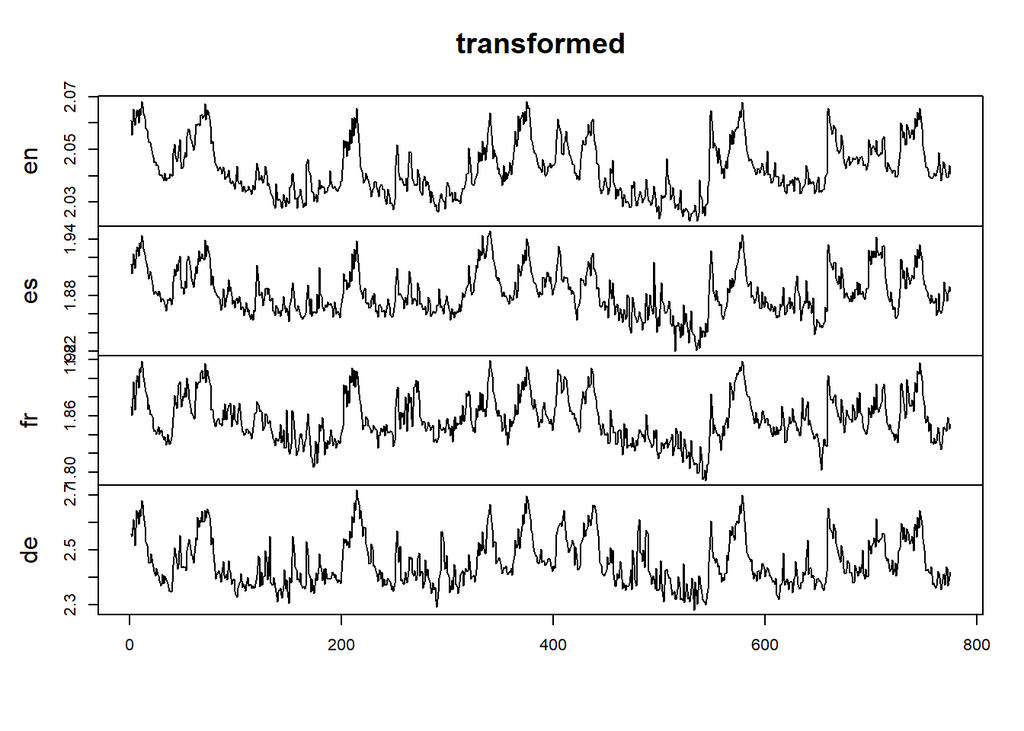

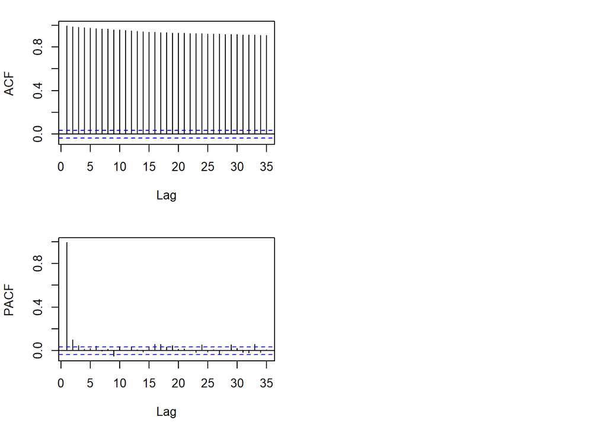

```r
lambda1 <- BoxCox.lambda(train[,1])
transformed.en <- BoxCox(train[,1],lambda=lambda1)
lambda2 <- BoxCox.lambda(train[,2])
transformed.fr <- BoxCox(train[,2],lambda=lambda2)
lambda3 <- BoxCox.lambda(train[,3])
transformed.es <- BoxCox(train[,3],lambda=lambda3)
lambda4 <- BoxCox.lambda(train[,4])
transformed.de <- BoxCox(train[,4],lambda=lambda4)
transformed=cbind(en=transformed.en,es=transformed.es,fr=transformed.fr,
                de=transformed.de)
tsdisplay(transformed)
```

## stationary test

```r
kpss.test(transformed.en) #is level stationary
```

```
##
##  KPSS Test for Level Stationarity
##
## data:  transformed.en
## KPSS Level = 0.378, Truncation lag parameter = 6, p-value =
## 0.08664
```

```r
adf.test(transformed.en)
```

```
##
##  Augmented Dickey-Fuller Test
##
## data:  transformed.en
## Dickey-Fuller = -4.996, Lag order = 9, p-value = 0.01
## alternative hypothesis: stationary
```

```r
adf.test(transformed.es)
```

```
##
##  Augmented Dickey-Fuller Test
##
## data:  transformed.es
## Dickey-Fuller = -5.6441, Lag order = 9, p-value = 0.01
## alternative hypothesis: stationary
```

```r
adf.test(transformed.fr)
```

```
##
##  Augmented Dickey-Fuller Test
##
## data:  transformed.fr
## Dickey-Fuller = -5.6695, Lag order = 9, p-value = 0.01
## alternative hypothesis: stationary
```

```r
adf.test(transformed.de)
```

```
##
##  Augmented Dickey-Fuller Test
##
## data:  transformed.de
## Dickey-Fuller = -5.8892, Lag order = 9, p-value = 0.01
## alternative hypothesis: stationary
```

# model fitting

## exponential smoothing

```r
#m.ses <- ses(transformed.en)
#summary(m.ses)
#m.holt <- holt(transformed.en)
#summary(m.holt)
m.ets <- ets(transformed.en) # best amoung the 3
summary(m.ets)
```

```
## ETS(M,N,N)
##
## Call:
##  ets(y = transformed.en)
##
##   Smoothing parameters:
##     alpha = 0.9542
##
##   Initial states:
##     l = 2.0608
##
##   sigma:  0.0018
##
##       AIC      AICc       BIC
## -3523.282 -3523.251 -3509.324
##
## Training set error measures:
##                         ME        RMSE         MAE          MPE      MAPE
## Training set -2.672513e-05 0.003687297 0.002711013 -0.001472833 0.1325645
##                  MASE         ACF1
## Training set 0.999373 0.0004279761
```

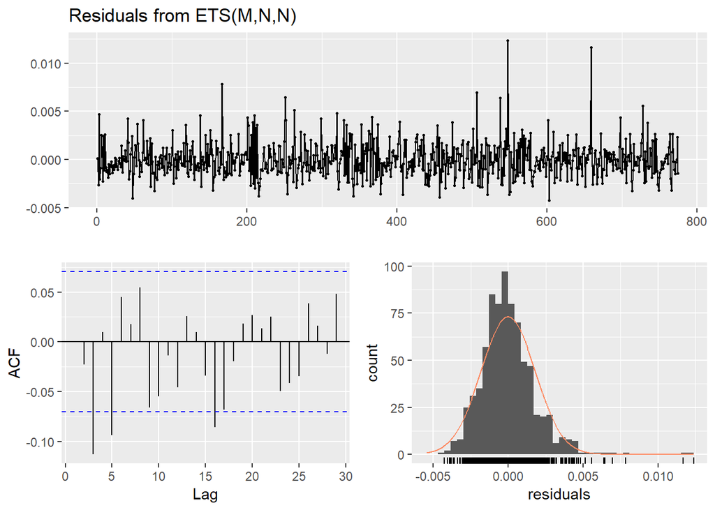

```
##
##  Ljung-Box test
##
## data:  Residuals from ETS(M,N,N)
## Q* = 27.231, df = 8, p-value = 0.0006449
##
## Model df: 2.   Total lags used: 10
```

```r
checkresiduals(m.ets)
```

residuals do not look good. we’ll not consider this model

```r
f.ets=forecast(m.ets,h=28)
error.ets=InvBoxCox(f.ets$mean,lambda=lambda1)-test[,1]
unique(InvBoxCox(f.ets$mean,lambda=lambda1)) #only gives 1 value in the preidction
```

```
## [1] 6017.425
```

## auto.arima

```r
# fit auto.arima on en
m.auto=auto.arima(train[,1],lambda=lambda1)
summary(m.auto)
```

```
## Series: train[, 1]
## ARIMA(4,0,2) with non-zero mean
## Box Cox transformation: lambda= -0.4826064
##
## Coefficients:
##           ar1     ar2     ar3     ar4     ma1     ma2    mean
##       -0.7326  0.7675  0.7293  0.0042  1.6715  0.8172  2.0428
## s.e.   0.1684  0.0685  0.1372  0.0473  0.1647  0.1291  0.0019
##
## sigma^2 estimated as 1.308e-05:  log likelihood=3259.97
## AIC=-6503.93   AICc=-6503.75   BIC=-6466.71
##
## Training set error measures:
##                    ME     RMSE      MAE       MPE    MAPE      MASE
## Training set 3185.942 30567.34 7144.078 -3.723988 22.4529 0.7655936
##                    ACF1
## Training set -0.1083828
```

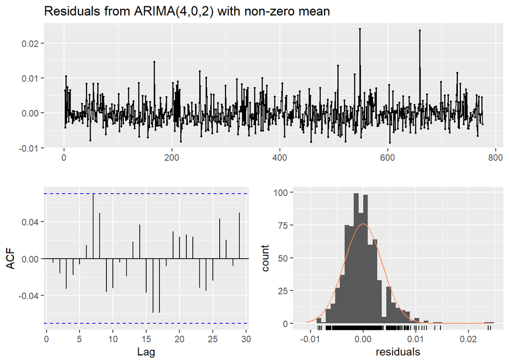

```
##
##  Ljung-Box test
##
## data:  Residuals from ARIMA(4,0,2) with non-zero mean
## Q* = 9.2117, df = 3, p-value = 0.0266
##
## Model df: 7.   Total lags used: 10
```

```r
checkresiduals(m.auto)
```

residuals look okay, pass ljung-box test if we lower the significance level.

```r
f.auto <- forecast(m.auto,h=28)
error.auto <- f.auto$mean-test[,1]
#plot(forecast(m.auto,h=28),include=100)
```

## arima

```r
eacf(transformed.en)
```

```
## AR/MA
##   0 1 2 3 4 5 6 7 8 9 10 11 12 13
## 0 x x x x x x x x x x x  x  x  x
## 1 o o x o x o o x o o o  o  o  o
## 2 x o x o o x o x o o o  o  o  o
## 3 x o o o o o o x o o o  o  o  o
## 4 x x o o o o o x o o o  o  o  o
## 5 x x o x o o o x o o o  o  o  o
## 6 x x x x x o o x o o o  o  o  o
## 7 x x x x o x o x o o o  o  o  o
```

```r
m.1.0 <- Arima(train[,1], order=c(1,0,0), lambda=lambda1)
m.1.1 <- Arima(train[,1], order=c(1,0,1),lambda=lambda1)
summary(m.1.0) # better
```

```
## Series: train[, 1]
## ARIMA(1,0,0) with non-zero mean
## Box Cox transformation: lambda= -0.4826064
##
## Coefficients:
##          ar1    mean
##       0.9327  2.0428
## s.e.  0.0129  0.0019
##
## sigma^2 estimated as 1.322e-05:  log likelihood=3253.29
## AIC=-6500.58   AICc=-6500.55   BIC=-6486.62
##
## Training set error measures:
##                   ME     RMSE      MAE       MPE     MAPE      MASE
## Training set 3147.97 31090.47 7381.518 -3.807397 22.60383 0.7910387
##                    ACF1
## Training set -0.1917853
```

```r
summary(m.1.1)
```

```
## Series: train[, 1]
## ARIMA(1,0,1) with non-zero mean
## Box Cox transformation: lambda= -0.4826064
##
## Coefficients:
##          ar1      ma1    mean
##       0.9344  -0.0117  2.0427
## s.e.  0.0137   0.0381  0.0019
##
## sigma^2 estimated as 1.324e-05:  log likelihood=3253.33
## AIC=-6498.67   AICc=-6498.62   BIC=-6480.06
##
## Training set error measures:
##                    ME    RMSE     MAE       MPE     MAPE      MASE
## Training set 3177.725 31051.9 7366.58 -3.747261 22.58665 0.7894379
##                    ACF1
## Training set -0.1812352
```

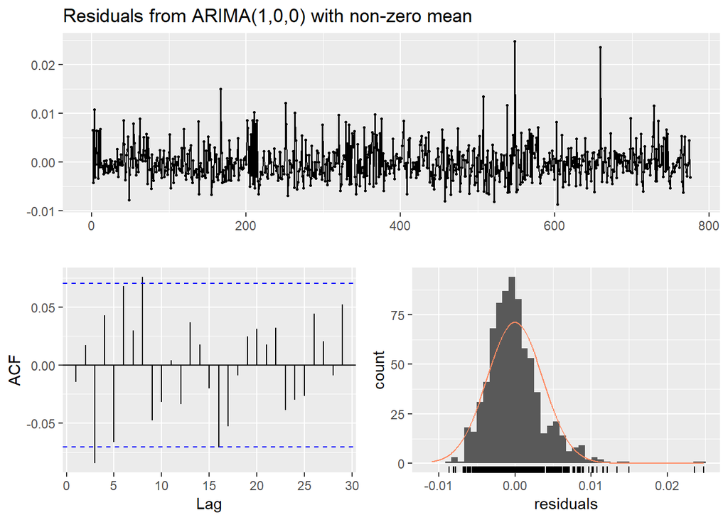

```
##
##  Ljung-Box test
##
## data:  Residuals from ARIMA(1,0,0) with non-zero mean
## Q* = 22.304, df = 8, p-value = 0.004383
##
## Model df: 2.   Total lags used: 10
```

```r
checkresiduals(m.1.0)
```

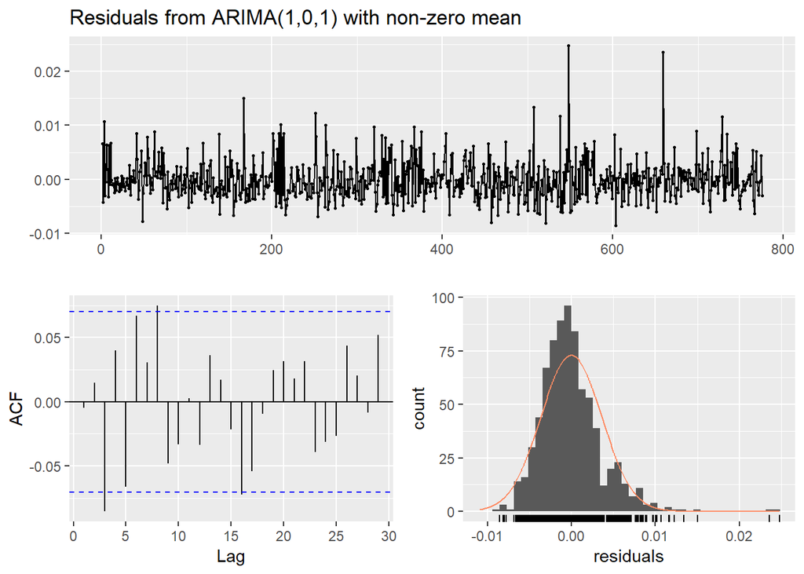

```
##
##  Ljung-Box test
##
## data:  Residuals from ARIMA(1,0,1) with non-zero mean
## Q* = 21.892, df = 7, p-value = 0.002652
##
## Model df: 3.   Total lags used: 10
```

```r
checkresiduals(m.1.1)
```

AIC from arima(1,0,0) is not much different than auto.arima, but this model is simpler. However the redisual p-value is far from passing the ljung-box test, so we’ll not consider this model.

```r
f.arima.100 <- forecast(m.1.0,h=28)
error.arima.100 <- f.arima.100$mean-test[,1]
```

## sarima

```r
# reconstruct ts with 365, assume annual seasonality
### not good!
#annual.en=ts(transformed.en,frequency=365)
# fit auto.arima on en
#m2=auto.arima(annual.en,seasonal=T, D=1)
#summary(m2)

# reconstruct ts with 30, assume monthly seasonality
### weekly is better.
#monthly.en=ts(transformed.en,frequency=30)
# fit auto.arima on en
#m.monthly=auto.arima(monthly.en,seasonal=T, D=1)
#summary(m.monthly)
#checkresiduals(m.monthly)
```

## weekly

```r
# fit auto.arima on weekly ts
m.weekly=auto.arima(train.weekly[,1],seasonal=T,lambda=lambda1)
summary(m.weekly)
```

```
## Series: train.weekly[, 1]
## ARIMA(3,0,2)(1,0,1)[7] with non-zero mean
## Box Cox transformation: lambda= -0.4826064
##
## Coefficients:
##           ar1     ar2     ar3     ma1     ma2    sar1     sma1    mean
##       -0.7796  0.7492  0.7451  1.7197  0.8654  0.5562  -0.4573  2.0428
## s.e.   0.0734  0.0352  0.0653  0.0598  0.0543  0.2532   0.2709  0.0019
##
## sigma^2 estimated as 1.296e-05:  log likelihood=3263.86
## AIC=-6509.72   AICc=-6509.48   BIC=-6467.84
##
## Training set error measures:
##                    ME     RMSE      MAE       MPE     MAPE      MASE
## Training set 3126.547 30712.47 7157.469 -3.735335 22.26676 0.4569681
##                    ACF1
## Training set -0.1147682
```

AIC is lower and loglikelyhood is better.

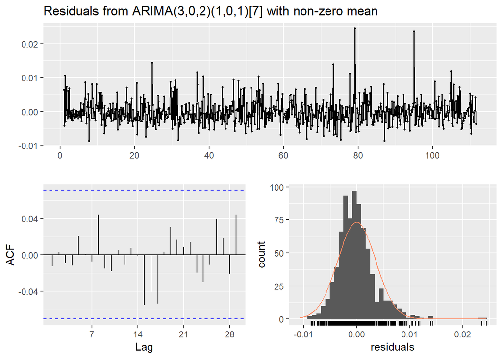

```
##
##  Ljung-Box test
##
## data:  Residuals from ARIMA(3,0,2)(1,0,1)[7] with non-zero mean
## Q* = 2.8275, df = 6, p-value = 0.8302
##
## Model df: 8.   Total lags used: 14
```

```r
checkresiduals(m.weekly)
```

the residuals also look like white noise and pass ljung-box test.

```r
f.sarima <- forecast(m.weekly,h=28)
error.sarima <- f.sarima$mean-test.weekly[,1]
```

## regression with arima error

adding the influence from es, fr, and de pages.

```r
xreg =cbind(transformed.es, transformed.fr, transformed.de)
m.reg <- auto.arima(train.weekly[,1],xreg =xreg,seasonal=T, lambda=lambda1)
summary(m.reg)
```

```
## Series: train.weekly[, 1]
## Regression with ARIMA(2,1,2) errors
## Box Cox transformation: lambda= -0.4826064
##
## Coefficients:
##           ar1     ar2     ma1      ma2  transformed.es  transformed.fr
##       -0.3616  0.4353  0.0044  -0.5897          0.1276          0.1076
## s.e.   0.1661  0.0908  0.1616   0.0829          0.0101          0.0092
##       transformed.de
##               0.0198
## s.e.          0.0025
##
## sigma^2 estimated as 5.481e-06:  log likelihood=3593.54
## AIC=-7171.08   AICc=-7170.89   BIC=-7133.86
##
## Training set error measures:
##                    ME     RMSE      MAE       MPE     MAPE      MASE
## Training set 311.7833 12379.86 3344.256 -1.655122 13.51809 0.2135138
##                    ACF1
## Training set 0.05532041
```

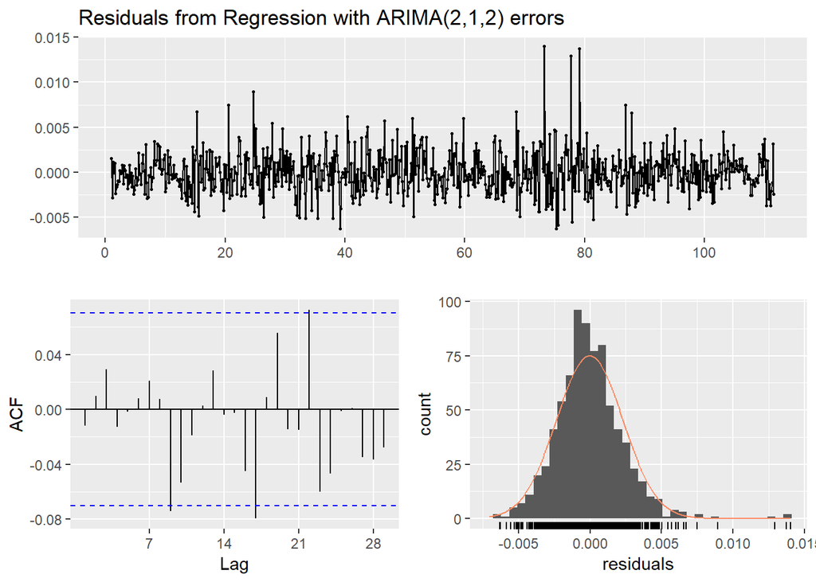

```
##
##  Ljung-Box test
##
## data:  Residuals from Regression with ARIMA(2,1,2) errors
## Q* = 8.9192, df = 7, p-value = 0.2585
##
## Model df: 7.   Total lags used: 14
```

```r
checkresiduals(m.reg)
```

further lowers AIC, residuals look good.

```r
transformed.test=cbind(transformed.es=BoxCox(test[,2],lambda=lambda2),
                       transformed.fr=BoxCox(test[,3],lambda=lambda3),
                       transformed.de=BoxCox(test[,4],lambda=lambda4))
f.xreg <- forecast(m.reg,xreg=transformed.test,h=28)
f.xreg
```

```
##          Point Forecast     Lo 80     Hi 80    Lo 95      Hi 95
## 111.7143       5581.775  4641.536  6834.673 4236.183   7673.672
## 111.8571       7041.603  5528.769  9260.124 4916.071  10878.886
## 112.0000       8210.939  6143.488 11505.951 5348.616  14104.925
## 112.1429       7187.416  5386.288 10049.932 4692.617  12301.734
## 112.2857       4993.897  3853.751  6716.046 3400.554   8007.401
## 112.4286       5350.171  4053.546  7371.882 3548.261   8933.681
## 112.5714       6414.408  4685.966  9288.177 4038.259  11649.344
## 112.7143       5637.390  4153.099  8068.564 3591.848  10037.250
## 112.8571       4735.933  3535.321  6657.165 3074.862   8178.420
## 113.0000       4438.961  3315.458  6235.064 2884.317   7655.925
## 113.1429       3789.482  2864.470  5237.585 2504.895   6360.527
## 113.2857       3949.395  2948.636  5550.383 2564.761   6817.735
## 113.4286       4373.223  3195.106  6331.674 2753.580   7940.525
## 113.5714       3969.953  2919.482  5696.009 2523.029   7098.003
## 113.7143       7037.116  4692.145 11652.879 3894.790  16156.149
## 113.8571       9821.003  6089.711 18298.229 4914.308  27988.087
## 114.0000       9448.562  5849.500 17651.839 4717.630  27063.438
## 114.1429       9658.919  5899.881 18466.722 4734.214  28900.513
## 114.2857      15827.328  8525.937 38385.960 6538.697  76354.153
## 114.4286      20612.615 10222.765 59976.105 7624.986 149753.125
## 114.5714      19221.831  9617.378 54791.792 7194.232 133031.460
## 114.7143      12242.244  6834.647 27629.209 5307.509  50807.547
## 114.8571      11417.869  6426.725 25361.057 5005.219  45866.812
## 115.0000      17397.613  8686.614 49831.100 6493.542 121775.918
## 115.1429      14479.461  7536.582 37770.111 5712.521  81844.039
## 115.2857      19140.651  9115.717 61453.875 6710.729 177179.689
## 115.4286      13576.543  7067.705 35402.903 5357.405  76683.012
## 115.5714      13639.730  7033.365 36317.283 5314.314  80715.379
```

```r
error.xreg <- f.xreg$mean-test.weekly[,1]
```

## VAR

```r
VARselect(transformed)
```

```
## $selection
## AIC(n)  HQ(n)  SC(n) FPE(n)
##      4      2      2      4
##
## $criteria
##                    1             2             3             4
## AIC(n) -3.726759e+01 -3.736971e+01 -3.738896e+01 -3.739569e+01
## HQ(n)  -3.722089e+01 -3.728565e+01 -3.726754e+01 -3.723692e+01
## SC(n)  -3.714628e+01 -3.715136e+01 -3.707357e+01 -3.698326e+01
## FPE(n)  6.529701e-17  5.895814e-17  5.783466e-17  5.744728e-17
##                    5             6             7             8
## AIC(n) -3.736920e+01 -3.736076e+01 -3.736741e+01 -3.734996e+01
## HQ(n)  -3.717307e+01 -3.712727e+01 -3.709656e+01 -3.704175e+01
## SC(n)  -3.685973e+01 -3.675424e+01 -3.666385e+01 -3.654935e+01
## FPE(n)  5.899093e-17  5.949320e-17  5.910225e-17  6.014687e-17
##                    9            10
## AIC(n) -3.734614e+01 -3.732560e+01
## HQ(n)  -3.700057e+01 -3.694268e+01
## SC(n)  -3.644849e+01 -3.633091e+01
## FPE(n)  6.038239e-17  6.164173e-17
```

```r
# 4 selected by aic, 2 by bic
m.var <- VAR(transformed,p=2,type = "both")
summary(m.var)
```

```
##
## VAR Estimation Results:
## =========================
## Endogenous variables: en, es, fr, de
## Deterministic variables: both
## Sample size: 773
## Log Likelihood: 10094.231
## Roots of the characteristic polynomial:
## 0.9297 0.8535 0.7926 0.7374 0.3012 0.2113 0.2079 0.02871
## Call:
## VAR(y = transformed, p = 2, type = "both")
##
##
## Estimation results for equation en:
## ===================================
## en = en.l1 + es.l1 + fr.l1 + de.l1 + en.l2 + es.l2 + fr.l2 + de.l2 + const + trend
##
##         Estimate Std. Error t value Pr(>|t|)
## en.l1  8.441e-01  5.455e-02  15.474   <2e-16 ***
## es.l1  2.052e-02  1.709e-02   1.201   0.2303
## fr.l1 -8.983e-03  1.563e-02  -0.575   0.5658
## de.l1  8.289e-03  4.101e-03   2.021   0.0436 *
## en.l2  1.186e-01  5.467e-02   2.169   0.0304 *
## es.l2 -1.159e-02  1.711e-02  -0.677   0.4983
## fr.l2 -8.865e-03  1.564e-02  -0.567   0.5709
## de.l2 -1.012e-02  4.091e-03  -2.475   0.0135 *
## const  9.706e-02  4.932e-02   1.968   0.0494 *
## trend  1.018e-07  6.034e-07   0.169   0.8660
## ---
## Signif. codes:  0 '***' 0.001 '**' 0.01 '*' 0.05 '.' 0.1 ' ' 1
##
##
## Residual standard error: 0.00362 on 763 degrees of freedom
## Multiple R-Squared: 0.8707,  Adjusted R-squared: 0.8692
## F-statistic: 570.9 on 9 and 763 DF,  p-value: < 2.2e-16
##
##
## Estimation results for equation es:
## ===================================
## es = en.l1 + es.l1 + fr.l1 + de.l1 + en.l2 + es.l2 + fr.l2 + de.l2 + const + trend
```

[output cut: 68 more lines]

```
##
##
## Covariance matrix of residuals:
##           en        es        fr        de
## en 1.310e-05 2.648e-05 2.643e-05 8.462e-05
## es 2.648e-05 1.152e-04 6.883e-05 2.347e-04
## fr 2.643e-05 6.883e-05 1.273e-04 2.339e-04
## de 8.462e-05 2.347e-04 2.339e-04 1.636e-03
##
## Correlation matrix of residuals:
##        en     es     fr     de
## en 1.0000 0.6814 0.6472 0.5779
## es 0.6814 1.0000 0.5683 0.5406
## fr 0.6472 0.5683 1.0000 0.5126
## de 0.5779 0.5406 0.5126 1.0000
```

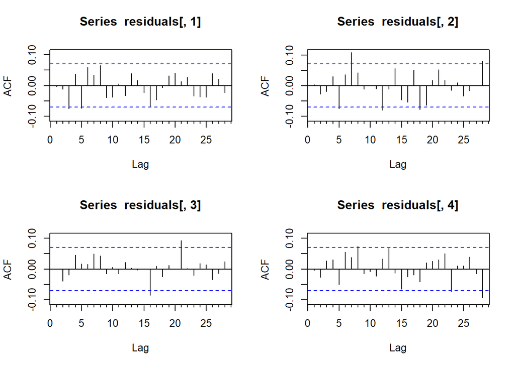

```r
residuals=residuals(m.var)
par(mfrow=c(2,2))
Acf(residuals[,1])
Acf(residuals[,2])
Acf(residuals[,3])
Acf(residuals[,4])
```

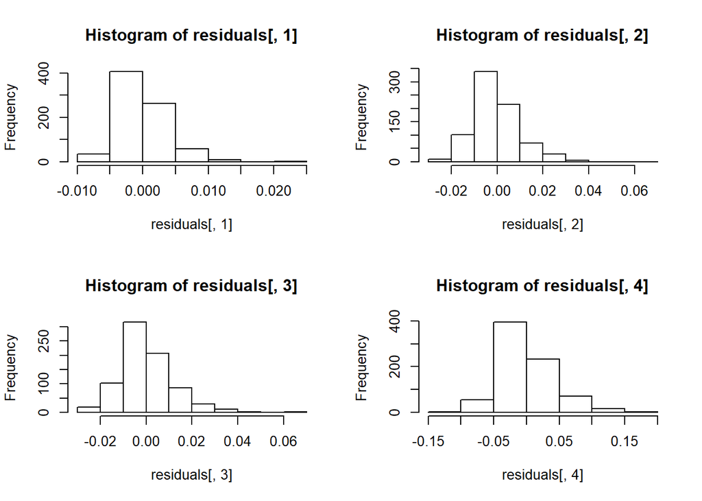

```r
par(mfrow=c(2,2))
hist(residuals[,1])
hist(residuals[,2])
hist(residuals[,3])
hist(residuals[,4])
```

```r
Box.test(residuals[,1],type="Ljung-Box",lag=12)
```

```
##
##  Box-Ljung test
##
## data:  residuals[, 1]
## X-squared = 20.233, df = 12, p-value = 0.0628
```

```r
Box.test(residuals[,2],type="Ljung-Box",lag=12)
```

```
##
##  Box-Ljung test
##
## data:  residuals[, 2]
## X-squared = 22.809, df = 12, p-value = 0.02939
```

```r
Box.test(residuals[,3],type="Ljung-Box",lag=12)
```

```
##
##  Box-Ljung test
##
## data:  residuals[, 3]
## X-squared = 7.7243, df = 12, p-value = 0.8063
```

```r
Box.test(residuals[,4],type="Ljung-Box",lag=12)
```

```
##
##  Box-Ljung test
##
## data:  residuals[, 4]
## X-squared = 13.273, df = 12, p-value = 0.3495
```

```r
f.var=forecast(m.var,h=28)
f.var.en=f.var$forecast$en$mean
error.var=InvBoxCox(f.var.en, lambda=lambda1)-test[,1]
#error.var = sqrt(mean(InvBoxCox(forecast(m.var, h=28)$forecast$transformed.en$mean, lambda=lambda1)-test[,1])^2)
```

## fourier transformation - dynamic harmonic regression

```r
transformed.weekly.en=ts(transformed.en,frequency = 7)
harmonic <- fourier(transformed.weekly.en,K=3)
m.fourier <- auto.arima(transformed.weekly.en,xreg=harmonic, seasonal=F)
summary(m.fourier)
```

```
## Series: transformed.weekly.en
## Regression with ARIMA(5,0,4) errors
##
## Coefficients:
##           ar1     ar2     ar3     ar4     ar5     ma1     ma2     ma3
##       -1.3313  0.1642  1.0876  0.5685  0.1222  2.2728  1.9899  0.7598
## s.e.   0.4157     NaN  0.6251     NaN     NaN  0.3921     NaN     NaN
##          ma4  intercept    S1-7   C1-7    S2-7    C2-7   S3-7   C3-7
##       0.1373     2.0429  -4e-04  8e-04  -2e-04  -3e-04  1e-04  1e-04
## s.e.     NaN     0.0020   2e-04  2e-04   1e-04   1e-04  1e-04  1e-04
##
## sigma^2 estimated as 1.275e-05:  log likelihood=3274.47
## AIC=-6514.94   AICc=-6514.13   BIC=-6435.84
##
## Training set error measures:
##                         ME        RMSE         MAE        MPE      MAPE
## Training set -3.823015e-05 0.003533254 0.002577319 -0.0021633 0.1260188
##                  MASE        ACF1
## Training set 0.413209 -0.01226784
```

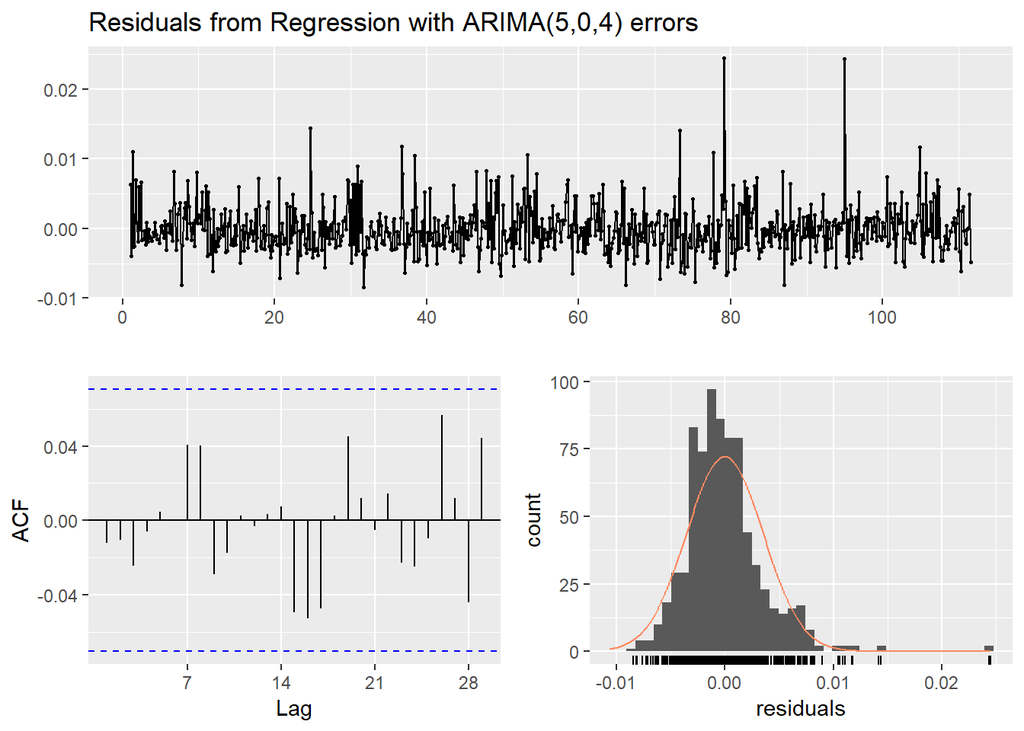

```
##
##  Ljung-Box test
##
## data:  Residuals from Regression with ARIMA(5,0,4) errors
## Q* = 11.817, df = 3, p-value = 0.008039
##
## Model df: 16.   Total lags used: 19
```

```r
checkresiduals(m.fourier)
```

residuals do not pass the Ljung-box test. couple of outliers in the residuals.

```r
new.harmonic <- fourier(transformed.weekly.en,K=3,h=28)
f.fourier <- forecast(m.fourier,xreg=new.harmonic, h=28)
error.fourier <- InvBoxCox(f.fourier$mean, lambda=lambda1)-as.numeric(test[,1])
```

## TBATS

```r
m.tbats <- tbats(transformed.en)
print(m.tbats)
```

```
## BATS(1, {3,1}, -, -)
##
## Call: tbats(y = transformed.en)
##
## Parameters
##   Alpha: 0.01801944
##   AR coefficients: 0.198666 0.700155 -0.047834
##   MA coefficients: 0.704137
##
## Seed States:
##          [,1]
## [1,] 2.058643
## [2,] 0.000000
## [3,] 0.000000
## [4,] 0.000000
## [5,] 0.000000
##
## Sigma: 0.003629454
## AIC: -3532.974
```

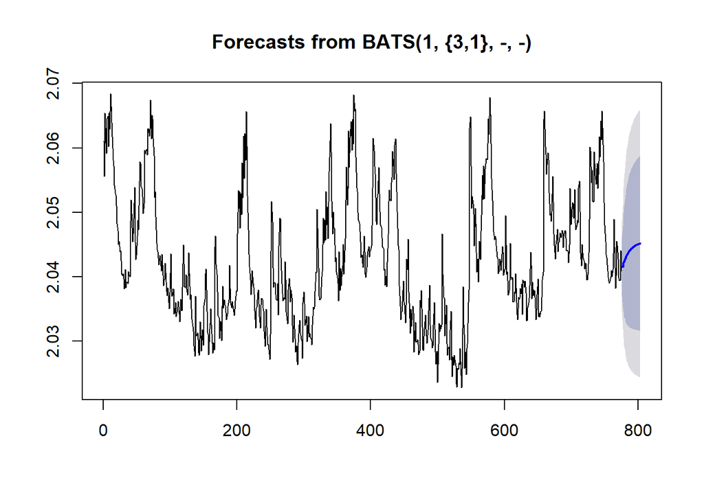

```r
plot(forecast(m.tbats, h=28))
```

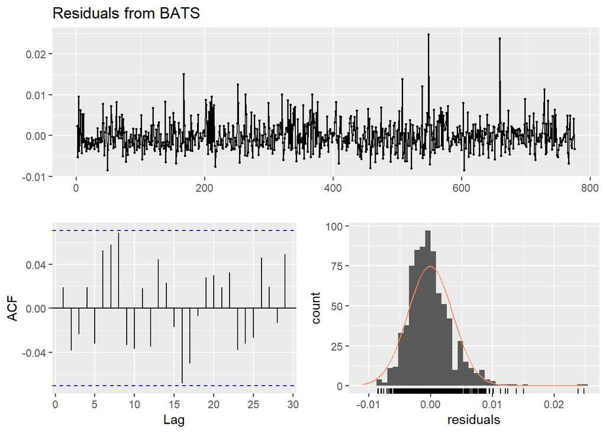

```
##
##  Ljung-Box test
##
## data:  Residuals from BATS
## Q* = 16.11, df = 3, p-value = 0.001077
##
## Model df: 10.   Total lags used: 13
```

```r
checkresiduals(m.tbats)
```

residuals do not pass ljung-box test.

## nnetar

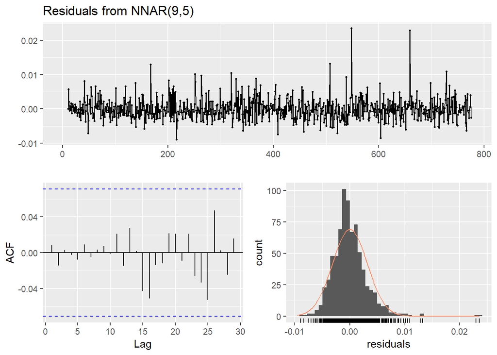

```r
nn <-nnetar(transformed.en)
checkresiduals(nn)
```

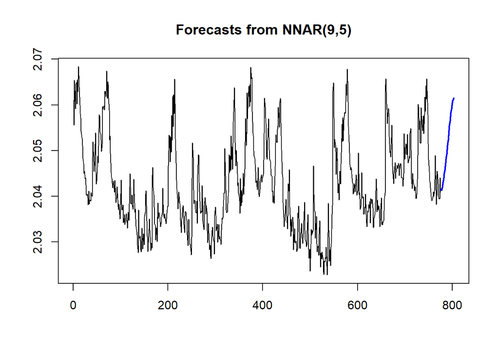

```r
f.nn=forecast(nn,h=28)
error.nn=InvBoxCox(f.nn$mean, lambda=lambda1)-(test[,1])
rmse.nn<-sqrt(mean(error.nn^2,na.rm=TRUE))
plot(forecast(nn, h=28))
```

## model comparison

```r
aicc <- cbind(ets=m.ets$aicc, auto.arima=m.auto$aicc, arima.100=m.1.0$aicc,
          sarima=m.weekly$aicc, xreg=m.reg$aicc, varma.AIC =AIC(m.var), fourier = m.fourier$aicc)
aicc
```

```
##            ets auto.arima arima.100   sarima      xreg varma.AIC   fourier
## [1,] -3523.251  -6503.746 -6500.547 -6509.48 -7170.887 -20108.46 -6514.131
```

```r
sort(aicc)
```

```
## [1] -20108.461  -7170.887  -6514.131  -6509.480  -6503.746  -6500.547
## [7]  -3523.251
```

```r
bic  <- cbind(ets=m.ets$bic, auto.arima=m.auto$bic, arima.100=m.1.0$bic,
          sarima=m.weekly$bic, xreg=m.reg$bic, varma =BIC(m.var), fourier = m.fourier$bic)
bic
```

```
##            ets auto.arima arima.100   sarima      xreg     varma   fourier
## [1,] -3509.324  -6466.711  -6486.62 -6467.84 -7133.863 -19922.45 -6435.841
```

```r
ll <-  cbind(ets=m.ets$loglik, auto.arima=m.auto$loglik, arima.100=m.1.0$loglik,
          sarima=m.weekly$loglik, xreg=m.reg$loglik, varma =logLik(m.var), fourier = m.fourier$loglik)
ll
```

```
##           ets auto.arima arima.100   sarima     xreg    varma fourier
## [1,] 1764.641   3259.967  3253.289 3263.858 3593.538 10094.23 3274.47
```

```r
rmse.ets <- sqrt(mean(error.ets^2,na.rm=TRUE))
rmse.auto <- sqrt(mean(error.auto^2,na.rm=TRUE))
rmse.arima.100 <- sqrt(mean(error.arima.100^2,na.rm=TRUE))
rmse.weekly <- sqrt(mean(error.sarima^2,na.rm=TRUE))
rmse.xreg <- sqrt(mean(error.xreg^2,na.rm=TRUE))
rmse.varma <- sqrt(mean(error.var^2,na.rm=TRUE))
rmse.fourier <- sqrt(mean(error.fourier^2,na.rm=TRUE))

rmse <- c(ets=rmse.ets, auto.arima = rmse.auto, arima.100=rmse.arima.100,
         sarima=rmse.weekly, xreg=rmse.xreg, varma=rmse.varma, fourier=rmse.fourier, nnetar=rmse.nn)
rmse
```

```
##        ets auto.arima  arima.100     sarima       xreg      varma
##   17392.61   17044.36   17040.78   17080.81   11406.77   16764.97
##    fourier     nnetar
##   17132.87   13296.06
```

```r
data <- rbind(aicc,bic,ll,rmse)
comparison <- as.data.frame(t(data),row.name=c('ets','auto.arima','arima(1,0,0)','sarima(weekly)', 'regression with arima error', 'varma', 'fourier'))
colnames(comparison)<-c('aic', 'bic', 'loglik', 'rmse')
comparison[order(comparison$rmse),]
```

|  | aic | bic | loglik | rmse |
| --- | --- | --- | --- | --- |
| regression with arima error | -7170.887 | -7133.863 | 3593.538 | 11406.77 |
| varma | -20108.461 | -19922.450 | 10094.231 | 16764.97 |
| arima(1,0,0) | -6500.547 | -6486.620 | 3253.289 | 17040.78 |
| auto.arima | -6503.746 | -6466.711 | 3259.967 | 17044.36 |
| sarima(weekly) | -6509.480 | -6467.840 | 3263.858 | 17080.81 |
| fourier | -6514.131 | -6435.841 | 3274.470 | 17132.87 |
| ets | -3523.251 | -3509.324 | 1764.641 | 17392.61 |

var(2) model has a much lower aic and bic then other models, and way bigger loglikelihood. However, this is computed from all 4 equations. could not compare it with other 1 equation models. But we can compare the RMSE on the reserved test set. regression with arima error model seems to be the best fit.

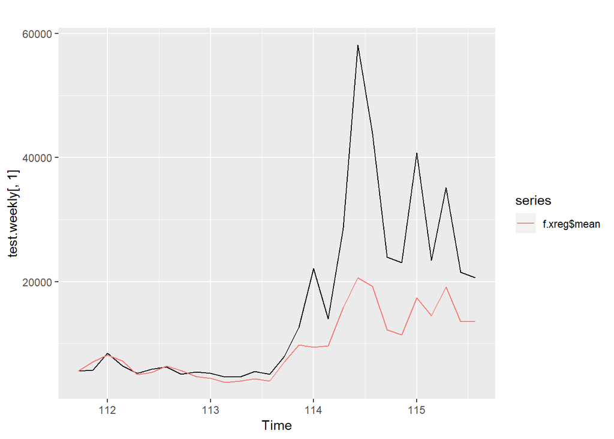

```r
autoplot(test.weekly[,1])+autolayer(f.xreg$mean)
```

error is bigger for the later time. it captures the general trend but underestimates the peak.

## forecasting 1 week out

```r
## using arima to predict es, fr and de
m.es <- auto.arima(tennis[,2],lambda='auto')
summary(m.es)
```

```
## Series: tennis[, 2]
## ARIMA(1,0,2) with non-zero mean
## Box Cox transformation: lambda= -0.5131604
##
## Coefficients:
##          ar1      ma1      ma2    mean
##       0.9126  -0.1117  -0.0553  1.8757
## s.e.  0.0182   0.0402   0.0378  0.0040
##
## sigma^2 estimated as 0.0001467:  log likelihood=2406
## AIC=-4802   AICc=-4801.92   BIC=-4778.56
##
## Training set error measures:
##                    ME     RMSE      MAE       MPE     MAPE      MASE
## Training set 335.7386 2436.105 579.4839 -3.460336 26.76442 0.7509494
##                    ACF1
## Training set 0.06577733
```

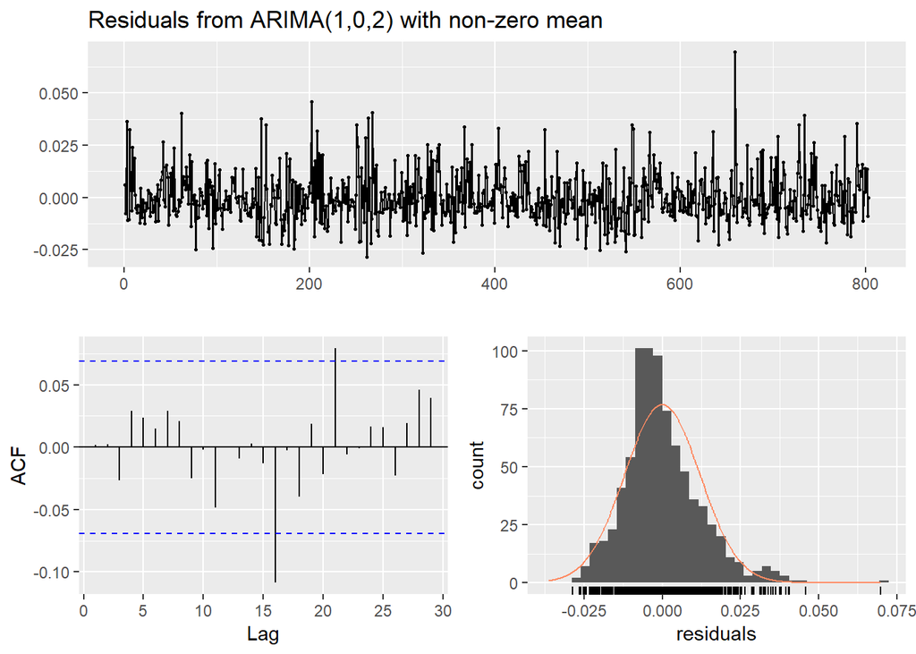

```
##
##  Ljung-Box test
##
## data:  Residuals from ARIMA(1,0,2) with non-zero mean
## Q* = 3.4277, df = 6, p-value = 0.7536
##
## Model df: 4.   Total lags used: 10
```

```r
checkresiduals(m.es)
```

```r
m.fr <- auto.arima(tennis[,3],lambda='auto')
summary(m.fr)
```

```
## Series: tennis[, 3]
## ARIMA(1,0,1) with non-zero mean
## Box Cox transformation: lambda= -0.512842
##
## Coefficients:
##          ar1      ma1    mean
##       0.9100  -0.1209  1.8787
## s.e.  0.0165   0.0400  0.0037
##
## sigma^2 estimated as 0.000118:  log likelihood=2492.87
## AIC=-4977.74   AICc=-4977.69   BIC=-4958.98
##
## Training set error measures:
##                    ME     RMSE     MAE       MPE     MAPE      MASE
## Training set 356.7594 3139.861 601.973 -3.052422 24.55874 0.7394736
##                   ACF1
## Training set 0.1578683
```

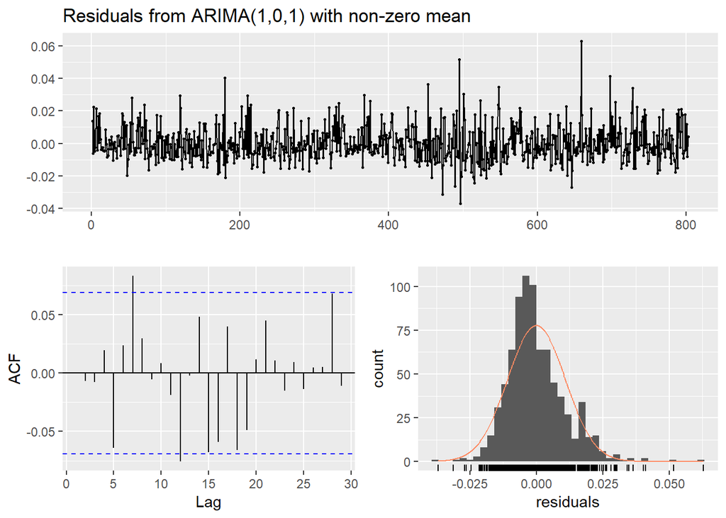

```
##
##  Ljung-Box test
##
## data:  Residuals from ARIMA(1,0,1) with non-zero mean
## Q* = 10.589, df = 7, p-value = 0.1576
##
## Model df: 3.   Total lags used: 10
```

```r
checkresiduals(m.fr)
```

```r
m.de <- auto.arima(tennis[,4],lambda = 'auto')
summary(m.de)
```

```
## Series: tennis[, 4]
## ARIMA(3,0,0) with non-zero mean
## Box Cox transformation: lambda= -0.3625696
##
## Coefficients:
##          ar1     ar2     ar3    mean
##       0.8102  0.0396  0.0436  2.4546
## s.e.  0.0352  0.0454  0.0353  0.0136
##
## sigma^2 estimated as 0.001724:  log likelihood=1416.72
## AIC=-2823.44   AICc=-2823.37   BIC=-2800
##
## Training set error measures:
##                    ME     RMSE      MAE       MPE     MAPE      MASE
## Training set 389.3231 4031.202 595.0305 -5.682306 30.50874 0.7014538
##                    ACF1
## Training set 0.05038729
```

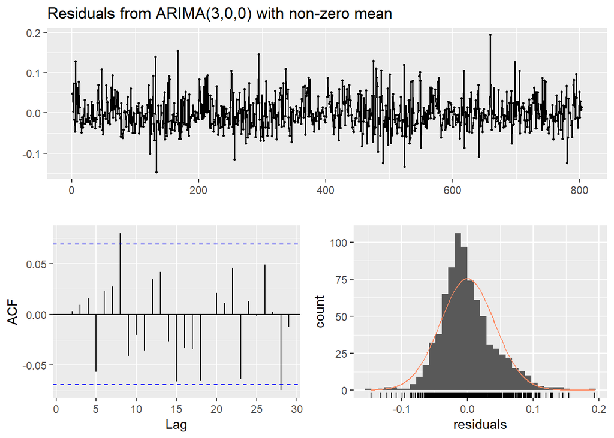

```
##
##  Ljung-Box test
##
## data:  Residuals from ARIMA(3,0,0) with non-zero mean
## Q* = 10.787, df = 6, p-value = 0.09517
##
## Model df: 4.   Total lags used: 10
```

```r
checkresiduals(m.de)
```

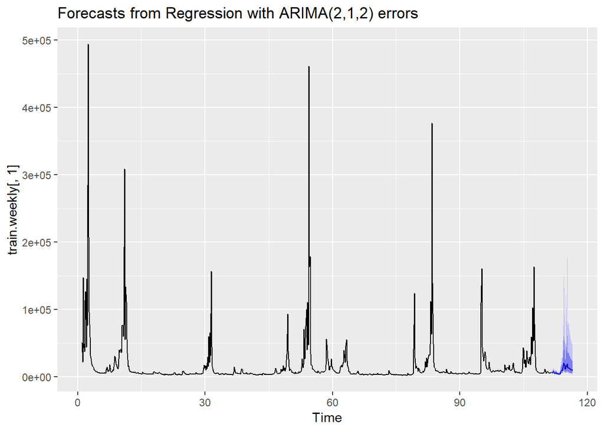

```r
# use predicted values to construct a new xreg to predict 1 more week of en
new.es <- forecast(m.es,h=7)$mean
new.fr <- forecast(m.fr,h=7)$mean
new.de <- forecast(m.de,h=7)$mean
# append the next 7 days prediction to the test period
new.xreg=cbind(transformed.es=BoxCox(append(test[,2],new.es),lambda=lambda2),
               transformed.fr=BoxCox(append(test[,3],new.fr),lambda=lambda3),
               transformed.de=BoxCox(append(test[,4],new.de),lambda=lambda4))
autoplot(forecast(m.reg,h=28+7, xreg=new.xreg),inlcude=50)
```